```python
import numpy as np
import matplotlib.pyplot as plt
```

## Basic idea:

we want to send some data

OFDM is a way to encode the data for sending

data stored as magnitude and phase in the frequency domain, and send out as wave

The transmitted wave is just: $\sum e^{i (2 \pi f + phase)}$

i.e. many sine wave of different freq, phase, magnitude sent in parallel (superpositioned)

## 流程

### Simple BPSK example

```python
N_sam = 16
# np.random.seed(1)


########################################################################################################

####################### transmit ######################
data_tx = np.floor(np.random.random(N_sam)*2)        # data to be transmitted
print('data_tx',''.join(map(str,map(int,data_tx))))
freqs_tx = data_tx*2-1                               # put data into freq spectrum, each is called a data carrier.
                                                     # bpsk: const magnitude, -1/1 phase

t_cplx_tx = np.fft.ifft(freqs_tx)                    # complex time domain data


########################################################################################################
# lets skip the part that transform complex time data back and forth to real signal
########################################################################################################

####################### recieve ######################
t_cplx_rx = t_cplx_tx + np.random.randn(N_sam)*.025    # recieved time domain data, has some noise
freqs_rx = np.fft.fft(t_cplx_rx)                      # recieved freq domain data
data_rx = (freqs_rx.real + 1)/2                       # recieved data

print('data_rx', ''.join(map(str,map(int,data_rx+.5))))
```

```
data_tx 1110000111000001
data_rx 1110000111000001
```

### 2 边一样, 收發成功! 很簡單吧?

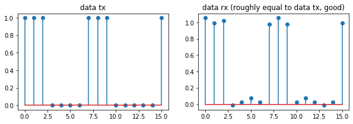

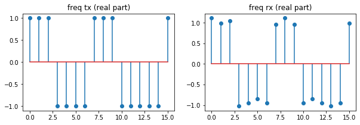

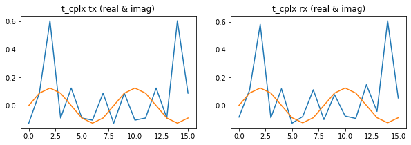

```python
### plot 出來看看

# plot data
plt.figure(None,(10,3))
plt.subplot(121)
plt.stem(data_tx,use_line_collection=True)
plt.title('data tx')
plt.subplot(122)
plt.stem(data_rx,use_line_collection=True)
plt.title('data rx (roughly equal to data tx, good)')


# plot freq domain
plt.figure(None,(10,3))
plt.subplot(121)
plt.stem(freqs_tx,use_line_collection=True)
plt.title('freq tx (real part)')
plt.subplot(122)
plt.stem(freqs_rx.real,use_line_collection=True)
# plt.stem(freqs_rx.imag,use_line_collection=True) ~= 0
plt.title('freq rx (real part)')

# plot time domain
plt.figure(None,(10,3))
plt.subplot(121)
plt.plot(t_cplx_tx.real)
plt.plot(t_cplx_tx.imag)
plt.title('t_cplx tx (real & imag)')
plt.subplot(122)
plt.plot(t_cplx_rx.real)
plt.plot(t_cplx_rx.imag)
plt.title('t_cplx rx (real & imag)')
```

# OFDM的原理

## 傳統FDM

~众所周知，~傳統fdm是在不同頻率 發送几個不同phase/amplitude 的 sine wave

為免互相干擾, 不同頻率的wave中間会留些空間, 浪費了帶寬

[figure not shown]

## OFDM

每个 carrier 在頻域实際上是一个`sinc` `(sin(f)/f)`, 在時域上就是一个很簡單的長方形

[figure not shown]

可以看到`sinc`是有很多零点的 (因為分母的`sin`)

当把几个`sinc` 的中心放在互相間的零点, 那中心就不会收到干擾了, 从而实現高效運用帶寬

[figure not shown]

## 流程和OFDM

那為什麼前面的流程就等价於OFDM呢?

# 其他

## Pilot Carrier

如果信號內容全是 接收端方未知的data, 接收端就無法得知哪裡是信號的起點,

所以需要一些相方約定內容來实現同步 (可能还有其他用途)

`pilot carrier` 就是固定了的一些carrier, 不帶data

而帶data的carrier 就叫`data carrier`

## CP (cyclic prefix)

能看懂可以看这个 https://read01.com/eP2Km7.html